# Countries by income category

In Module 3, you will practice and reinforce your `ggplot2` skills by making Figure 1.1 from The Global Findex Database 2017, which you can see here:

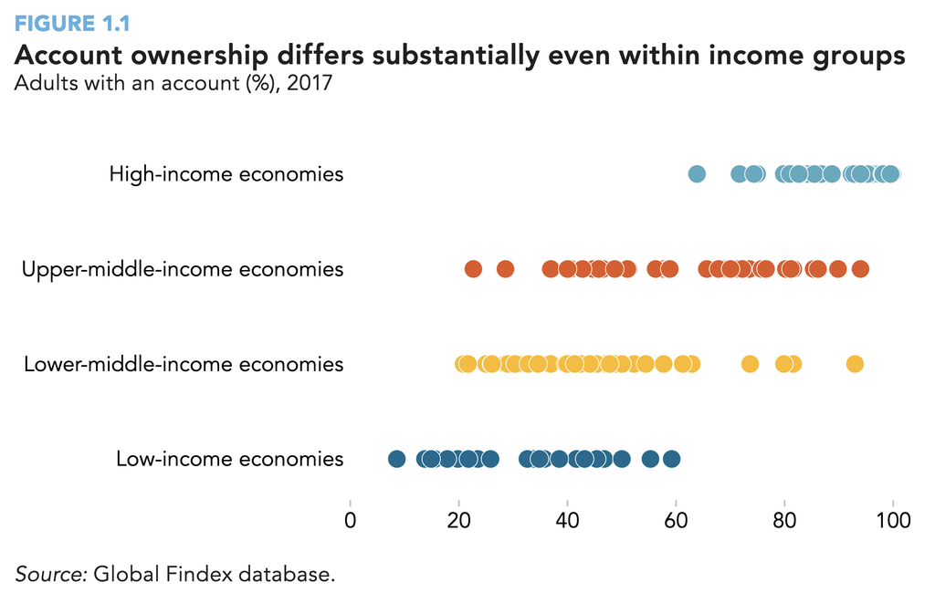

**Image description: Figure 1.1 from The Global Findex Database 2017** (source: https://openknowledge.worldbank.org/handle/10986/29510)

The x-axis (the left-right direction) is a percentage, interpreted as a specific country’s overall account ownership. You will use the dataset we’ve already analyzed in Module 2, which is saved in your GlobalFindex project folder on your computer in a file named `micro_world.csv`, to calculate these percentages. However, the y-axis (the up-down direction) of this figure, which separates these percentages by the World-Bank-designated income level of each country, is not available in `micro_world.csv`. These data are freely available from the World Bank (https://datahelpdesk.worldbank.org/knowledgebase/articles/906519-world-bank-country-and-lending-groups). For completeness, we describe exactly how we obtained these data from this url, but note that **a reduced version of the data are available for download directly from the course website, as described in the last paragraph.**

The data are taken from the .xlsx file that the link “[historical classification by income in XLSX format](http://databank.worldbank.org/data/download/site-content/OGHIST.xlsx)” points to:

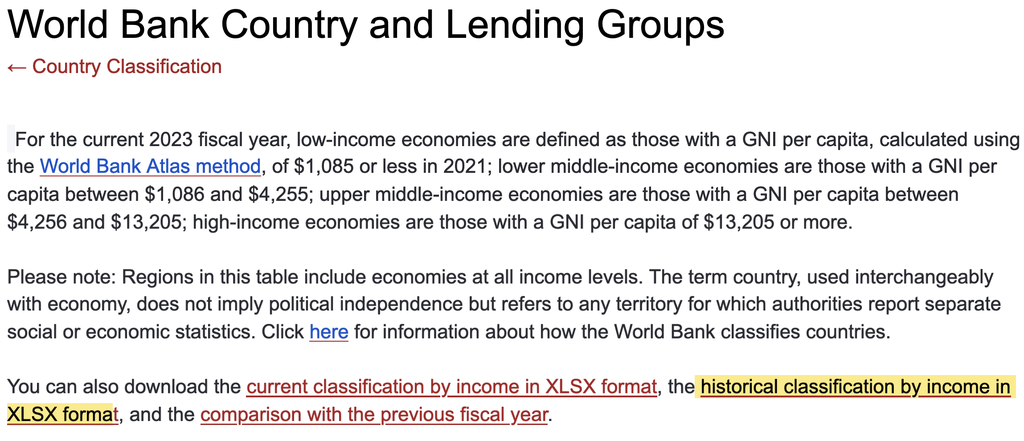

**Image description: screen capture from https://datahelpdesk.worldbank.org/knowledgebase/articles/906519-world-bank-country-and-lending-groups as of 31-Oct-2022. The link pointing to country-level income is highlighted**

If you navigate to that second tab of the linked .xlsx file, which is entitled “Country Analytical History”, we need the information between rows 12 and 229 (inclusive) for two columns: column A identifies each country using its World Bank abbreviation, and column AE provides each country’s designated income level in the year 2017 (the same year as The Global Findex Database 2017). Column AE has four possible values: L (low-income), LM (lower-middle-income), UM (upper-middle-income), and H (high-income), which correspond to y-axis labels on Figure 1.1.

You can download directly from the course website a .csv version of the income-level data that contains all of and only the information that is relevant for Figure 1.1. The file is named `wb_income.csv`. In this file we’ve renamed the values of the income levels (‘L’ is changed to ‘1Low’, ‘LM’ is changed to ‘2LowerMid’, ‘UM’ is changed to ‘3UpperMid’, and ‘H’ is changed to ‘4High’). Download and save this file into your GlobalFindex project folder before proceeding to the Practice Quiz for Module 3, Lesson 1. Once you’ve read them into R, you will need to join these two datasets using skills that you’ve already learned in Module 2.